# Reproducible research : Course Project 1

D.Dakhno

April 2016

## Contents

This document covers the following assignment aspects:  
1. Code for reading in the dataset and/or processing the data  
2. Histogram of the total number of steps taken each day  
3. Mean and median number of steps taken each day  
4. Time series plot of the average number of steps taken  
5. The 5-minute interval that, on average, contains the maximum number of steps  
6. Code to describe and show a strategy for imputing missing data  
7. Histogram of the total number of steps taken each day after missing values are imputed  
8. Panel plot comparing the average number of steps taken per 5-minute interval across weekdays and weekends

## Code for reading in the dataset and/or processing the data

The following chunk of code ensure the file with activity records is available (if yet not here) and the activity data are read into the data table for further analysis

```r
if (!file.exists("activity.csv")) {
     if (!file.exists("activity.zip")) {
         fil <- download.file("https://d396qusza40orc.cloudfront.net/repdata%2Fdata%2Factivity.zip", destfile = "activity.zip", mode = "wb")
         unzip("activity.zip")
     }
     else { unzip("activity.zip") }
}
if(!dir.exists("figure")) dir.create("figure")

library(data.table)
activity <- data.table(read.csv("activity.csv",colClasses = c("numeric","Date","numeric")))
```

```r
head(activity)
```

```
##    steps       date interval
## 1:    NA 2012-10-01        0
## 2:    NA 2012-10-01        5
## 3:    NA 2012-10-01       10
## 4:    NA 2012-10-01       15
## 5:    NA 2012-10-01       20
## 6:    NA 2012-10-01       25
```

```r
summary(activity)
```

```
##      steps             date               interval
##  Min.   :  0.00   Min.   :2012-10-01   Min.   :   0.0
##  1st Qu.:  0.00   1st Qu.:2012-10-16   1st Qu.: 588.8
##  Median :  0.00   Median :2012-10-31   Median :1177.5
##  Mean   : 37.38   Mean   :2012-10-31   Mean   :1177.5
##  3rd Qu.: 12.00   3rd Qu.:2012-11-15   3rd Qu.:1766.2
##  Max.   :806.00   Max.   :2012-11-30   Max.   :2355.0
##  NA's   :2304
```

```r
str(activity)
```

```
## Classes 'data.table' and 'data.frame':   17568 obs. of  3 variables:
##  $ steps   : num  NA NA NA NA NA NA NA NA NA NA ...
##  $ date    : Date, format: "2012-10-01" "2012-10-01" ...
##  $ interval: num  0 5 10 15 20 25 30 35 40 45 ...
##  - attr(*, ".internal.selfref")=<externalptr>
```

## Histogram of the total number of steps taken each day

First we are summarizing the data by date for the following steps.

```r
library(dplyr, verbose = FALSE, quietly = TRUE)
activity_summarized <- activity%>%group_by(date)%>%summarize(SumSteps = sum(steps), MeanSteps = mean(steps), MedianSteps = median(steps))
head(activity_summarized)
```

```
##         date SumSteps MeanSteps MedianSteps
## 1 2012-10-01       NA        NA          NA
## 2 2012-10-02      126   0.43750           0
## 3 2012-10-03    11352  39.41667           0
## 4 2012-10-04    12116  42.06944           0
## 5 2012-10-05    13294  46.15972           0
## 6 2012-10-06    15420  53.54167           0
```

Generating the historgram (although the sums are for each day, the days itself are not represented in the figure, only the distribution of the sums).

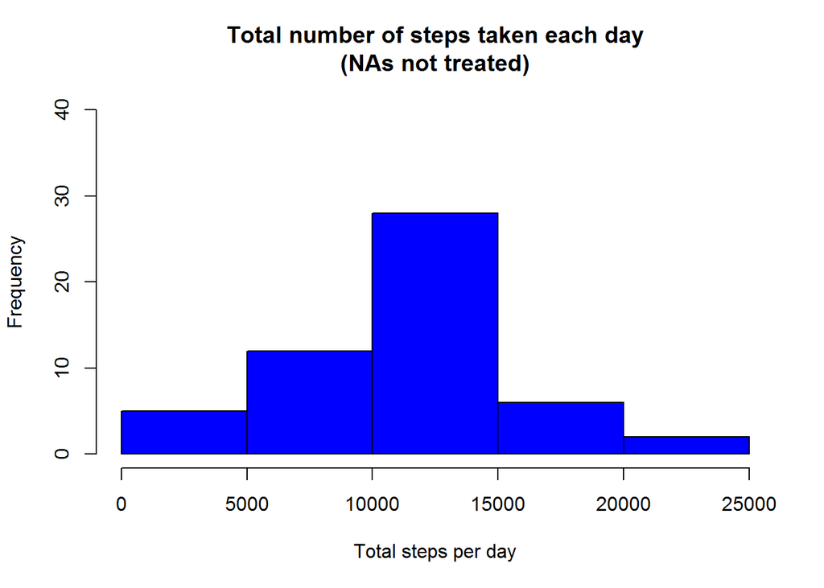

```r
hist(activity_summarized$SumSteps, main = "Total number of steps taken each day\n(NAs not treated)", xlab = "Total steps per day", col = "blue", ylim = c(0,40))
```

```r
#Saving the figure for further recycling
dev.copy(png, file = "figure/Total_number_steps_with_NA.png")
```

```r
dev.off()
```

## Mean and median number of steps taken each day

Using the before summarized data print the mean and median number of steps taken each day

```r
#For  comparisons in future...
activity_summarized_before <- copy(activity_summarized)
activity_summarized$SumSteps <- NULL
activity_summarized
```

```
## Source: local data table [61 x 3]
##
##          date MeanSteps MedianSteps
##        (date)     (dbl)       (dbl)
## 1  2012-10-01        NA          NA
## 2  2012-10-02   0.43750           0
## 3  2012-10-03  39.41667           0
## 4  2012-10-04  42.06944           0
## 5  2012-10-05  46.15972           0
## 6  2012-10-06  53.54167           0
## 7  2012-10-07  38.24653           0
## 8  2012-10-08        NA          NA
## 9  2012-10-09  44.48264           0
## 10 2012-10-10  34.37500           0
## ..        ...       ...         ...
```

A lot of strange “0” as median values for the number of steps compared to the non-null means suggest, more than the half of time intervals were lazy.

## Time series plot of the average number of steps taken or What is the average daily activity pattern?

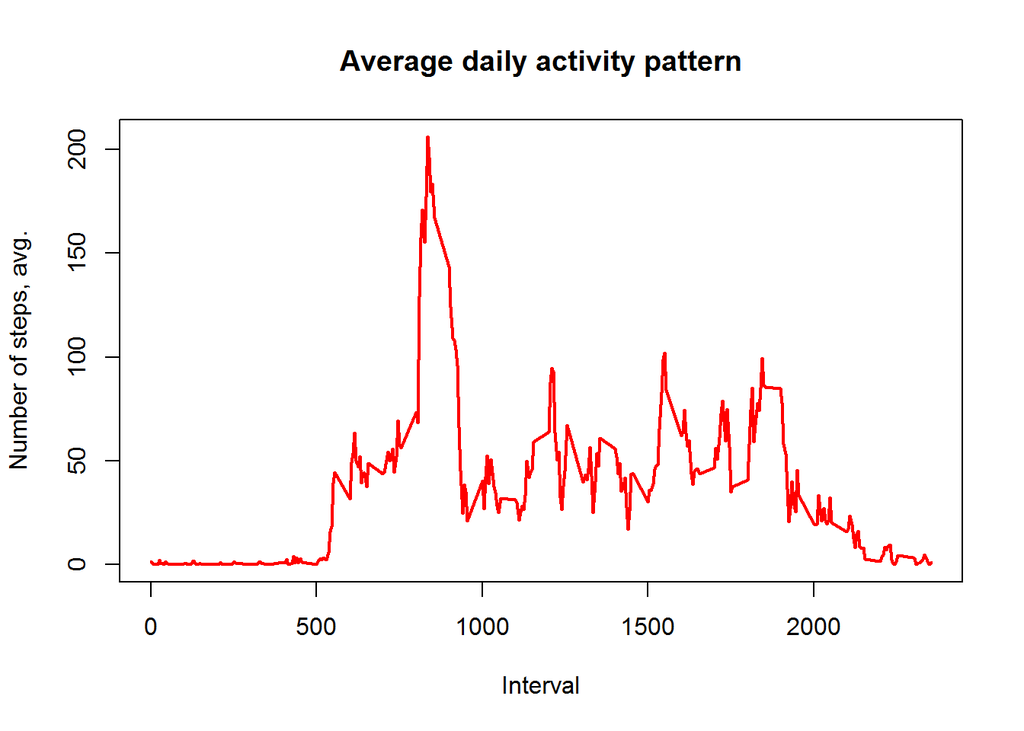

```r
activity_summarized_interval <- aggregate(steps ~ interval, activity, mean)
plot(x = activity_summarized_interval$interval, y = activity_summarized_interval$steps, type="l", xlab = "Interval", ylab = "Number of steps, avg." , main = "Average daily activity pattern", lwd = 2, col = "red")
```

## The 5-minute interval that, on average, contains the maximum number of steps

```r
with(activity_summarized_interval,interval[which.max(steps)])
```

```
## [1] 835
```

So, the time of the peak activity is on average about 8:35 AM

## Code to describe and show a strategy for imputing missing data

### Calculate and report the total number of missing values in the dataset (i.e. the total number of rows with NAs)

```r
sapply(activity, function(x) sum(is.na(x)))
```

```
##    steps     date interval
##     2304        0        0
```

So, the total number of rows with NAs is 2304 (all missing values are in the column “steps”)

### Devising a strategy for filling in all of the missing values in the dataset.

Out of all unsophisticated strategies we choose here setting up the mean for that 5-minute interval (over all the days) instead of the missing value

```r
activity_summarized <- activity%>%group_by(interval)%>%summarize(MeanSteps = mean(steps, na.rm = TRUE))
activity_summarized$interval <- as.factor(activity_summarized$interval)
setkey(activity_summarized, interval)
#NB! Data tables are approached by reference, so copy() here to preserve the original data
activity_completed <- copy(activity)

for (i in seq(along = activity_completed$interval)) {
    if (is.na(activity_completed[i,]$steps)) {
        activity_completed[i,]$steps <- activity_summarized[as.character(activity_completed[i,]$interval)]$MeanSteps
    }
}
```

Compare

```r
activity
```

```
##        steps       date interval
##     1:    NA 2012-10-01        0
##     2:    NA 2012-10-01        5
##     3:    NA 2012-10-01       10
##     4:    NA 2012-10-01       15
##     5:    NA 2012-10-01       20
##    ---
## 17564:    NA 2012-11-30     2335
## 17565:    NA 2012-11-30     2340
## 17566:    NA 2012-11-30     2345
## 17567:    NA 2012-11-30     2350
## 17568:    NA 2012-11-30     2355
```

```r
activity_completed
```

```
##            steps       date interval
##     1: 1.7169811 2012-10-01        0
##     2: 0.3396226 2012-10-01        5
##     3: 0.1320755 2012-10-01       10
##     4: 0.1509434 2012-10-01       15
##     5: 0.0754717 2012-10-01       20
##    ---
## 17564: 4.6981132 2012-11-30     2335
## 17565: 3.3018868 2012-11-30     2340
## 17566: 0.6415094 2012-11-30     2345
## 17567: 0.2264151 2012-11-30     2350
## 17568: 1.0754717 2012-11-30     2355
```

## Histogram of the total number of steps taken each day after missing values are imputed

Computing the summarized statistics over the completed values

```r
activity_summarized <- activity_completed%>%group_by(date)%>%summarize(SumSteps = sum(steps, na.rm = TRUE), MeanSteps = mean(steps, na.rm = TRUE), MedianSteps = median(steps, na.rm = TRUE))
activity_summarized
```

```
## Source: local data table [61 x 4]
##
##          date SumSteps MeanSteps MedianSteps
##        (date)    (dbl)     (dbl)       (dbl)
## 1  2012-10-01 10766.19  37.38260    34.11321
## 2  2012-10-02   126.00   0.43750     0.00000
## 3  2012-10-03 11352.00  39.41667     0.00000
## 4  2012-10-04 12116.00  42.06944     0.00000
## 5  2012-10-05 13294.00  46.15972     0.00000
## 6  2012-10-06 15420.00  53.54167     0.00000
## 7  2012-10-07 11015.00  38.24653     0.00000
## 8  2012-10-08 10766.19  37.38260    34.11321
## 9  2012-10-09 12811.00  44.48264     0.00000
## 10 2012-10-10  9900.00  34.37500     0.00000
## ..        ...      ...       ...         ...
```

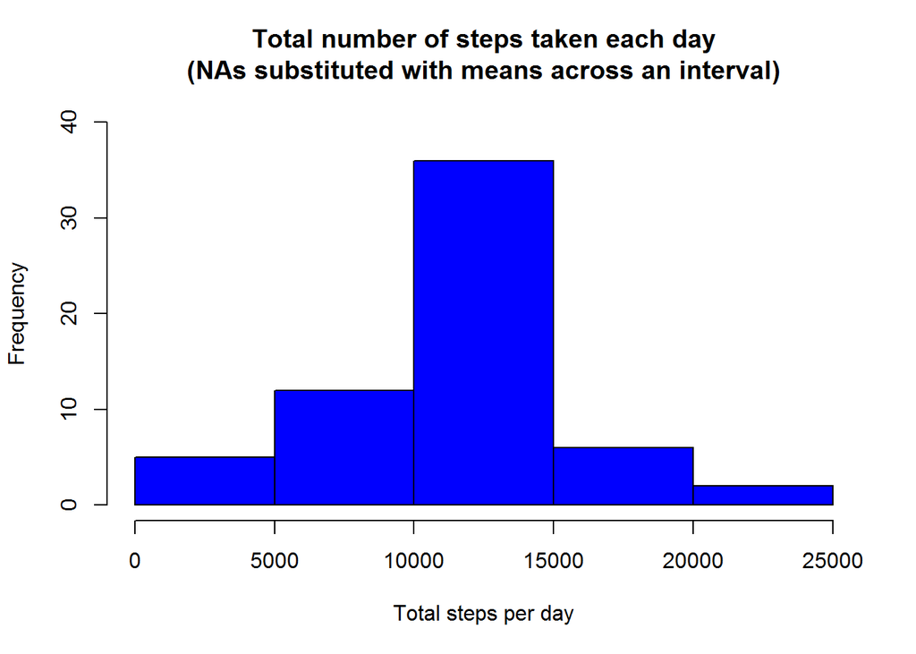

```r
hist(activity_summarized$SumSteps, main = "Total number of steps taken each day\n(NAs substituted with means across an interval)", xlab = "Total steps per day", col = "blue", ylim = c(0,40))
```

Do these values differ from the estimates from the first part of the assignment? Anyway!

```r
activity_summarized_before
```

```
## Source: local data table [61 x 4]
##
##          date SumSteps MeanSteps MedianSteps
##        (date)    (dbl)     (dbl)       (dbl)
## 1  2012-10-01       NA        NA          NA
## 2  2012-10-02      126   0.43750           0
## 3  2012-10-03    11352  39.41667           0
## 4  2012-10-04    12116  42.06944           0
## 5  2012-10-05    13294  46.15972           0
## 6  2012-10-06    15420  53.54167           0
## 7  2012-10-07    11015  38.24653           0
## 8  2012-10-08       NA        NA          NA
## 9  2012-10-09    12811  44.48264           0
## 10 2012-10-10     9900  34.37500           0
## ..        ...      ...       ...         ...
```

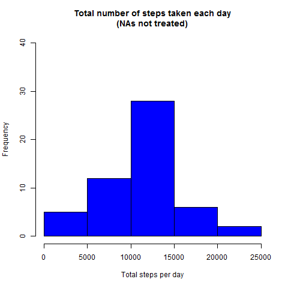